# CPSC 330 - Applied Machine Learning

Zhengling Jiang

- Understanding the problem
- Data splitting
- EDA
- Feature engineering
- Preprocessing and transformations
- Baseline model
- Linear models
- Different classifiers
- Feature selection
- Hyperparameter optimization
- Interpretation and feature importances
- Results on the test set
- Explaining predictions
- Summary of the results

## Imports

```python
import os

%matplotlib inline
import sys

import matplotlib.pyplot as plt
import numpy as np
import pandas as pd
import seaborn as sns
import xgboost as xgb
from sklearn.compose import ColumnTransformer, make_column_transformer
from sklearn.dummy import DummyClassifier
from sklearn.ensemble import RandomForestClassifier
from sklearn.impute import SimpleImputer
from sklearn.linear_model import LogisticRegression
from sklearn.metrics import (
    classification_report,
    confusion_matrix,
    f1_score,
    make_scorer,
    plot_confusion_matrix,
)
from sklearn.model_selection import (
    GridSearchCV,
    RandomizedSearchCV,
    cross_val_score,
    cross_validate,
    train_test_split,
)
from sklearn.pipeline import Pipeline, make_pipeline
from sklearn.preprocessing import OneHotEncoder, OrdinalEncoder, StandardScaler
from sklearn.svm import SVC
from xgboost import XGBClassifier
```

```python
# import warnings
# warnings.filterwarnings('ignore', category=DeprecationWarning)
```

## 1. Introduction

In this mini project, I will be working on a classification problem of predicting whether a customer will cancel the reservation they have made at a hotel. I will use [Reservation Cancellation Prediction Dataset](https://www.kaggle.com/datasets/gauravduttakiit/reservation-cancellation-prediction?select=train__dataset.csv). In this data set, there are about 18.000 examples and 18 features (including the target), and the goal is to estimate whether a person will cancel their booking; this column is labeled "booking_status" in the data (1 = canceled).

1. Building a model to predict whether a customer will cancel a booking can bring many benefits to a hotel. For example, if the likelihood of customer cancellation is high, the hotel can set a high deposit. Since the question is to predict the label, we may need to build a classifier model. There are 18,000 examples and 18 features in the dataset, which is representative enough.

```python
df = pd.read_csv('train_reservation.csv')
df.head()
```

|  | no_of_adults | no_of_children | no_of_weekend_nights | no_of_week_nights | type_of_meal_plan | required_car_parking_space | room_type_reserved | lead_time | arrival_year | arrival_month | arrival_date | market_segment_type | repeated_guest | no_of_previous_cancellations | no_of_previous_bookings_not_canceled | avg_price_per_room | no_of_special_requests | booking_status |
| --- | --- | --- | --- | --- | --- | --- | --- | --- | --- | --- | --- | --- | --- | --- | --- | --- | --- | --- |
| 0 | 2 | 0 | 1 | 4 | 0 | 0 | 0 | 118 | 2017 | 12 | 28 | 1 | 0 | 0 | 0 | 110.80 | 2 | 0 |
| 1 | 2 | 1 | 0 | 2 | 0 | 0 | 0 | 17 | 2018 | 4 | 14 | 1 | 0 | 0 | 0 | 145.00 | 0 | 1 |
| 2 | 1 | 0 | 1 | 5 | 0 | 0 | 0 | 349 | 2018 | 10 | 4 | 0 | 0 | 0 | 0 | 96.67 | 0 | 1 |
| 3 | 1 | 0 | 2 | 4 | 0 | 0 | 0 | 69 | 2018 | 6 | 12 | 0 | 0 | 0 | 0 | 120.00 | 0 | 1 |
| 4 | 2 | 0 | 0 | 4 | 1 | 0 | 0 | 11 | 2018 | 1 | 20 | 1 | 0 | 0 | 0 | 69.50 | 1 | 0 |

## 2. Data splitting

1. Split the data into train and test portions.

```python
train_df, test_df = train_test_split(df, test_size = 0.3, random_state = 123)
train_df.head()
```

|  | no_of_adults | no_of_children | no_of_weekend_nights | no_of_week_nights | type_of_meal_plan | required_car_parking_space | room_type_reserved | lead_time | arrival_year | arrival_month | arrival_date | market_segment_type | repeated_guest | no_of_previous_cancellations | no_of_previous_bookings_not_canceled | avg_price_per_room | no_of_special_requests | booking_status |
| --- | --- | --- | --- | --- | --- | --- | --- | --- | --- | --- | --- | --- | --- | --- | --- | --- | --- | --- |
| 15946 | 2 | 0 | 2 | 3 | 0 | 0 | 1 | 45 | 2018 | 11 | 24 | 1 | 0 | 0 | 0 | 96.90 | 2 | 0 |
| 12132 | 2 | 0 | 1 | 2 | 0 | 0 | 0 | 273 | 2018 | 5 | 13 | 0 | 0 | 0 | 0 | 95.00 | 0 | 1 |
| 217 | 2 | 0 | 0 | 2 | 0 | 0 | 0 | 68 | 2017 | 9 | 29 | 0 | 0 | 0 | 0 | 65.00 | 0 | 0 |
| 3858 | 2 | 0 | 0 | 3 | 0 | 0 | 1 | 41 | 2018 | 2 | 4 | 1 | 0 | 0 | 0 | 82.45 | 0 | 1 |
| 17908 | 2 | 0 | 1 | 1 | 0 | 0 | 0 | 159 | 2018 | 4 | 9 | 0 | 0 | 0 | 0 | 70.00 | 1 | 0 |

## 3. EDA

1. Perform exploratory data analysis on the train set.
2. Perform two summary statistics and two visualizations.
3. Summarize observations about the data.
4. Pick appropriate metric/metrics for assessment.

#### Exploratory data analysis

```python
train_df.info()
```

```
<class 'pandas.core.frame.DataFrame'>
Int64Index: 12695 entries, 15946 to 15725
Data columns (total 18 columns):
 #   Column                                Non-Null Count  Dtype
---  ------                                --------------  -----
 0   no_of_adults                          12695 non-null  int64
 1   no_of_children                        12695 non-null  int64
 2   no_of_weekend_nights                  12695 non-null  int64
 3   no_of_week_nights                     12695 non-null  int64
 4   type_of_meal_plan                     12695 non-null  int64
 5   required_car_parking_space            12695 non-null  int64
 6   room_type_reserved                    12695 non-null  int64
 7   lead_time                             12695 non-null  int64
 8   arrival_year                          12695 non-null  int64
 9   arrival_month                         12695 non-null  int64
 10  arrival_date                          12695 non-null  int64
 11  market_segment_type                   12695 non-null  int64
 12  repeated_guest                        12695 non-null  int64
 13  no_of_previous_cancellations          12695 non-null  int64
 14  no_of_previous_bookings_not_canceled  12695 non-null  int64
 15  avg_price_per_room                    12695 non-null  float64
 16  no_of_special_requests                12695 non-null  int64
 17  booking_status                        12695 non-null  int64
dtypes: float64(1), int64(17)
memory usage: 1.8 MB
```

We can see that there is no null value in the dataset and all features are numeric.

#### Summary statistics

```python
train_df.describe(include='all')
```

|  | no_of_adults | no_of_children | no_of_weekend_nights | no_of_week_nights | type_of_meal_plan | required_car_parking_space | room_type_reserved | lead_time | arrival_year | arrival_month | arrival_date | market_segment_type | repeated_guest | no_of_previous_cancellations | no_of_previous_bookings_not_canceled | avg_price_per_room | no_of_special_requests | booking_status |
| --- | --- | --- | --- | --- | --- | --- | --- | --- | --- | --- | --- | --- | --- | --- | --- | --- | --- | --- |
| count | 12695.000000 | 12695.000000 | 12695.000000 | 12695.000000 | 12695.000000 | 12695.000000 | 12695.000000 | 12695.000000 | 12695.000000 | 12695.000000 | 12695.000000 | 12695.0000 | 12695.000000 | 12695.000000 | 12695.000000 | 12695.000000 | 12695.000000 | 12695.000000 |
| mean | 1.851359 | 0.106892 | 0.809137 | 2.202915 | 0.317290 | 0.032690 | 0.338007 | 85.579913 | 2017.820402 | 7.431587 | 15.743127 | 0.8000 | 0.025207 | 0.022371 | 0.158724 | 103.519186 | 0.625286 | 0.326113 |
| std | 0.515134 | 0.398709 | 0.870111 | 1.419864 | 0.630232 | 0.177831 | 0.775014 | 87.294409 | 0.383868 | 3.084243 | 8.765916 | 0.6444 | 0.156759 | 0.355431 | 1.788642 | 35.370949 | 0.790905 | 0.468808 |
| min | 0.000000 | 0.000000 | 0.000000 | 0.000000 | 0.000000 | 0.000000 | 0.000000 | 0.000000 | 2017.000000 | 1.000000 | 1.000000 | 0.0000 | 0.000000 | 0.000000 | 0.000000 | 0.000000 | 0.000000 | 0.000000 |
| 25% | 2.000000 | 0.000000 | 0.000000 | 1.000000 | 0.000000 | 0.000000 | 0.000000 | 16.000000 | 2018.000000 | 5.000000 | 8.000000 | 0.0000 | 0.000000 | 0.000000 | 0.000000 | 80.100000 | 0.000000 | 0.000000 |
| 50% | 2.000000 | 0.000000 | 1.000000 | 2.000000 | 0.000000 | 0.000000 | 0.000000 | 57.000000 | 2018.000000 | 8.000000 | 16.000000 | 1.0000 | 0.000000 | 0.000000 | 0.000000 | 99.450000 | 0.000000 | 0.000000 |
| 75% | 2.000000 | 0.000000 | 2.000000 | 3.000000 | 0.000000 | 0.000000 | 0.000000 | 127.000000 | 2018.000000 | 10.000000 | 23.000000 | 1.0000 | 0.000000 | 0.000000 | 0.000000 | 120.600000 | 1.000000 | 1.000000 |
| max | 4.000000 | 3.000000 | 7.000000 | 17.000000 | 3.000000 | 1.000000 | 6.000000 | 443.000000 | 2018.000000 | 12.000000 | 31.000000 | 4.0000 | 1.000000 | 13.000000 | 58.000000 | 375.500000 | 5.000000 | 1.000000 |

All features are numeric and they have different ranges. Means show the central tendency of every feature.

```python
train_df['booking_status'].value_counts()
```

```
0    8555
1    4140
Name: booking_status, dtype: int64
```

There are 8555 rows in the train_df where the 'booking_status' is not canceled, and there 4140 rows in the train_df where the 'booking_status' is canceled. The classes are unbalanced.

#### Graphs

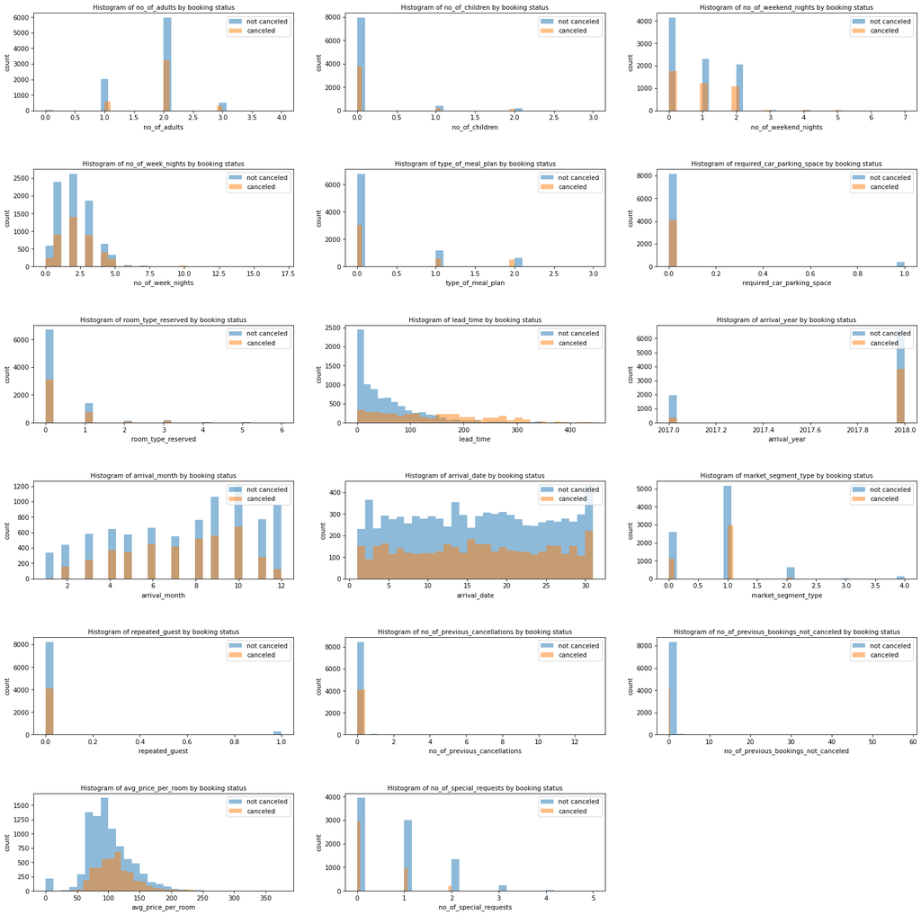

```python
negative_examples = train_df.query("booking_status == 0")
positive_examples = train_df.query("booking_status == 1")

X_train = train_df.drop(columns=['booking_status'])
features = X_train.columns

ncol = 3
nrow = 6

sub_index = 1

# plt.figure(figsize=(20,20))
plt.figure(figsize=(25,25), dpi=75)


for i in features:
    plt.subplot(nrow, ncol, sub_index)
    plt.hist(negative_examples[i], bins = 30, alpha=0.5, label='not canceled')
    plt.hist(positive_examples[i], bins = 30, alpha=0.5, label='canceled')
    plt.legend(loc='upper right')
    plt.xlabel(i, fontsize=10)
    plt.ylabel('count', fontsize=10)
    plt.title('Histogram of ' + i + ' by booking status', fontsize=10)
    sub_index += 1

plt.subplots_adjust(hspace=0.6)
plt.show()
```

From these histograms, there is a clear threshold for market_segment_type, no_of_previous_bookings_not_canceled, and no_of_special_requests. For other features, the threshold is not very clear.

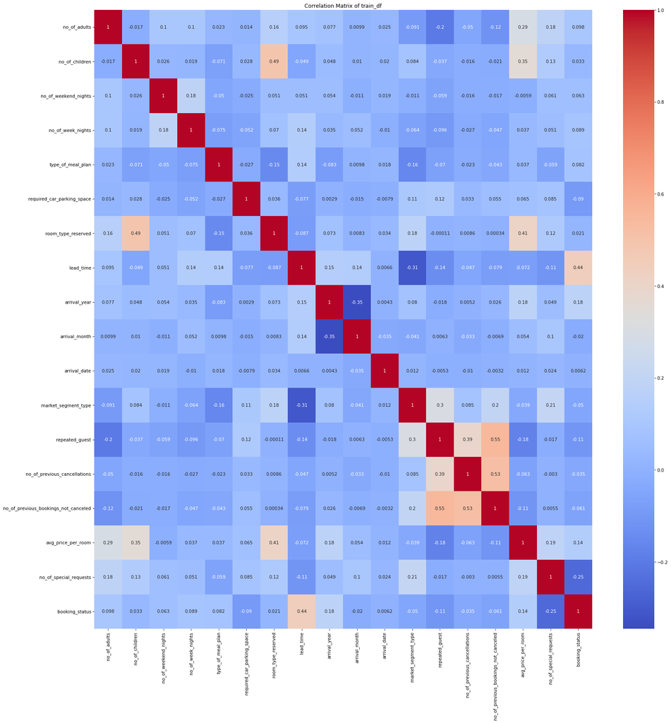

```python
corr_matrix = train_df.corr()

# Create the heatmap
plt.figure(figsize=(25,25), dpi=75)
sns.heatmap(corr_matrix, annot=True, cmap='coolwarm')

plt.title('Correlation Matrix of train_df')

plt.show()
```

The heatmap displays the correlations between each feature including the target variable. Lead_time seems to have the strongest correlation with booking_status. Arrival_time seems to have the weakest correlation with booking_status.

#### Metrics

I plan to use F1 score. F1 score is a suitable metric for unbalanced target classes because it takes into account both precision and recall, which are important in such cases where misclassification of minority class instances is critical. It balances the trade-off between precision and recall, providing a better measure of overall model performance.

## 4. Feature engineering

Extract new features relevant for the problem, and I will use them in the following analysis.

- I plan to create a new feature 'previous_cancellation_rate' by diving 'no_of_previous_cancellations' by the sum of 'no_of_previous_cancellations', and 'no_of_previous_bookings_not_canceled', ignore the NaN values for now, using impute function in the preprocessing section

```python
train_df['previous_cancellation_rate'] = train_df['no_of_previous_cancellations'] / (train_df['no_of_previous_cancellations'] +
                                                                                train_df['no_of_previous_bookings_not_canceled'])

test_df['previous_cancellation_rate'] = test_df['no_of_previous_cancellations'] / (test_df['no_of_previous_cancellations'] +
                                                                                test_df['no_of_previous_bookings_not_canceled'])


X_train = train_df.drop(columns=['booking_status'])
y_train = train_df['booking_status']
X_test = test_df.drop(columns=['booking_status'])
y_test = test_df['booking_status']
```

## 5. Preprocessing and transformations

1. Identify different feature types and the transformations.
2. Define a column transformer.

```python
categorical_features = ['type_of_meal_plan', 'room_type_reserved', 'market_segment_type']
binary_features = ['required_car_parking_space', 'repeated_guest']
numeric_features = list(set(X_train.columns) - set(categorical_features) - set(binary_features))

preprocessor = make_column_transformer (
        (make_pipeline(SimpleImputer(), StandardScaler()),
         numeric_features,
        ),
        (make_pipeline(SimpleImputer(strategy = 'most_frequent'), OneHotEncoder(handle_unknown="ignore")),
        categorical_features,
        ),
        (SimpleImputer(strategy = 'most_frequent'), binary_features), # binary features are already be transformed into 0 or 1
    )
```

## 6. Baseline model

1. Use one `scikit-learn`'s baseline model and report results.

```python
dum_pipe = make_pipeline(preprocessor, DummyClassifier(strategy="prior"))

# I plan to use F1 score
f1_scores = cross_val_score(dum_pipe, X_train, y_train, scoring="f1")

print(f"Mean f1 score: {f1_scores.mean():.3f} (std: {f1_scores.std():.3f})")
```

```
Mean f1 score: 0.000 (std: 0.000)
```

The f1 score is zero, it's not surprising. The baseline model is DummyClassifier model with 'strategy = prior', which always predict the most frequent class and our target classes are imbalanced. So, there are no true positive predictions. We need to find more appropriate model.

## 7. Linear models

1. Use logistic regression as a first real attempt.
2. Carry out hyperparameter tuning to explore different values for the complexity hyperparameter `C`.
3. Report validation scores along with standard deviation.
4. Summarize the results.

```python
pipe_lr = make_pipeline(preprocessor, LogisticRegression(max_iter = 1000))

param_grid = {
    "logisticregression__C": [0.001, 0.01, 0.1, 1.0, 10, 100],
    "logisticregression__class_weight": [None, {0:1, 1: 2}, 'balanced'],
}

grid_scores = GridSearchCV(
    pipe_lr, param_grid, cv=5, n_jobs=-1, scoring = 'f1', return_train_score = True
)

grid_scores.fit(X_train, y_train)

print("best params: ", grid_scores.best_params_)
print("best f1 score: ", grid_scores.best_score_)

results = grid_scores.cv_results_

for mean_score, std_score, params in zip(
    results["mean_test_score"],
    results["std_test_score"],
    results["params"],
):
    print(f"Mean F1 Score: {mean_score:.3f} (Std: {std_score:.3f}) for {params}")
```

```
best params:  {'logisticregression__C': 10, 'logisticregression__class_weight': {0: 1, 1: 2}}
best f1 score:  0.699689637735832
Mean F1 Score: 0.568 (Std: 0.006) for {'logisticregression__C': 0.001, 'logisticregression__class_weight': None}
Mean F1 Score: 0.691 (Std: 0.012) for {'logisticregression__C': 0.001, 'logisticregression__class_weight': {0: 1, 1: 2}}
Mean F1 Score: 0.693 (Std: 0.012) for {'logisticregression__C': 0.001, 'logisticregression__class_weight': 'balanced'}
Mean F1 Score: 0.660 (Std: 0.009) for {'logisticregression__C': 0.01, 'logisticregression__class_weight': None}
Mean F1 Score: 0.698 (Std: 0.009) for {'logisticregression__C': 0.01, 'logisticregression__class_weight': {0: 1, 1: 2}}
Mean F1 Score: 0.698 (Std: 0.009) for {'logisticregression__C': 0.01, 'logisticregression__class_weight': 'balanced'}
Mean F1 Score: 0.675 (Std: 0.007) for {'logisticregression__C': 0.1, 'logisticregression__class_weight': None}
Mean F1 Score: 0.698 (Std: 0.007) for {'logisticregression__C': 0.1, 'logisticregression__class_weight': {0: 1, 1: 2}}
Mean F1 Score: 0.698 (Std: 0.008) for {'logisticregression__C': 0.1, 'logisticregression__class_weight': 'balanced'}
Mean F1 Score: 0.678 (Std: 0.008) for {'logisticregression__C': 1.0, 'logisticregression__class_weight': None}
Mean F1 Score: 0.700 (Std: 0.008) for {'logisticregression__C': 1.0, 'logisticregression__class_weight': {0: 1, 1: 2}}
Mean F1 Score: 0.698 (Std: 0.007) for {'logisticregression__C': 1.0, 'logisticregression__class_weight': 'balanced'}
Mean F1 Score: 0.677 (Std: 0.007) for {'logisticregression__C': 10, 'logisticregression__class_weight': None}
Mean F1 Score: 0.700 (Std: 0.007) for {'logisticregression__C': 10, 'logisticregression__class_weight': {0: 1, 1: 2}}
Mean F1 Score: 0.698 (Std: 0.007) for {'logisticregression__C': 10, 'logisticregression__class_weight': 'balanced'}
Mean F1 Score: 0.677 (Std: 0.007) for {'logisticregression__C': 100, 'logisticregression__class_weight': None}
Mean F1 Score: 0.700 (Std: 0.008) for {'logisticregression__C': 100, 'logisticregression__class_weight': {0: 1, 1: 2}}
Mean F1 Score: 0.698 (Std: 0.007) for {'logisticregression__C': 100, 'logisticregression__class_weight': 'balanced'}
```

Logistic Regression model with hyperparameter tuning can be a not bad first real attempt, but we may find a better one.

## 8. Different classifiers

1. Explore 3 other models aside from logistic regression. RandomForestClassifier, XGBoost Classifier, and SVC.
2. Summarize results.

```python
def mean_std_cross_val_scores(model, X_train, y_train, **kwargs):
    """
    Returns mean and std of cross validation

    Parameters
    ----------
    model :
        scikit-learn model
    X_train : numpy array or pandas DataFrame
        X in the training data
    y_train :
        y in the training data

    Returns
    ----------
        pandas Series with mean scores from cross_validation
    """

    scores = cross_validate(model, X_train, y_train, **kwargs)

    mean_scores = pd.DataFrame(scores).mean()
    std_scores = pd.DataFrame(scores).std()
    out_col = []

    for i in range(len(mean_scores)):
        out_col.append((f"%0.3f (+/- %0.3f)" % (mean_scores[i], std_scores[i])))

    return pd.Series(data=out_col, index=mean_scores.index)
```

```python
results = {}

# RandomForestClassifier
rfc = make_pipeline(preprocessor, RandomForestClassifier(random_state=123, n_jobs=-1, max_depth = 7,
                                                         n_estimators = 100, class_weight = {0: 1, 1: 2}))

results["Random forests"] = mean_std_cross_val_scores(
    rfc, X_train, y_train, return_train_score=True, scoring='f1')


# XGBoost Classifier
xgb = make_pipeline(preprocessor, XGBClassifier(random_state=123, eval_metric="logloss", verbosity=0, n_estimators = 100,
                                               max_depth = 10, n_jobs = -1))

results['XGBoost'] = mean_std_cross_val_scores(
    xgb, X_train, y_train, scoring = 'f1', return_train_score = True
)


# SVC
svc = make_pipeline(preprocessor, SVC(gamma = 0.1, C = 5))

results['SVC'] = mean_std_cross_val_scores(
    svc, X_train, y_train, scoring = 'f1', return_train_score = True
)

print("Logistic Regression: ", grid_scores.best_score_)
pd.DataFrame(results).T
```

```
Logistic Regression:  0.699689637735832
```

|  | fit_time | score_time | test_score | train_score |
| --- | --- | --- | --- | --- |
| Random forests | 0.236 (+/- 0.006) | 0.026 (+/- 0.001) | 0.756 (+/- 0.014) | 0.768 (+/- 0.002) |
| XGBoost | 0.747 (+/- 0.008) | 0.008 (+/- 0.000) | 0.806 (+/- 0.010) | 0.993 (+/- 0.001) |
| SVC | 2.675 (+/- 0.040) | 0.867 (+/- 0.006) | 0.753 (+/- 0.009) | 0.817 (+/- 0.003) |

All the three models can beat the logistic regression. XGBoost model is better than other three models.

## 9. Feature selection

Select relevant features. I will try `RFECV` to see whether the results improve with feature selection.

In linear model section, for LogisticRegression, we got best params: 'C': 10, 'class_weight': {0: 1, 1: 2} and best f1 score: 0.7. I will still use these parameters.

```python
from sklearn.feature_selection import RFECV

X_train_scaled = preprocessor.fit_transform(X_train)

rfe_cv = RFECV(LogisticRegression(max_iter=1000), cv=10)
rfe_cv.fit(X_train_scaled, y_train)
print('Original number of features:', X_train_scaled.shape[1])
print('Number of selected features:', sum(rfe_cv.support_), '\n\n')

rfe_pipe = make_pipeline(
    preprocessor,
    RFECV(LogisticRegression(max_iter=1000), cv=10),
    LogisticRegression(C = 10, class_weight = {0:1, 1:2})
)

pd.DataFrame(cross_validate(rfe_pipe, X_train, y_train, scoring = 'f1', return_train_score=True)).mean()
```

```
Original number of features: 31
Number of selected features: 20
```

[output not shown]

```
fit_time       13.517439
score_time      0.005321
test_score      0.699395
train_score     0.699834
dtype: float64
```

The f1 score is 0.699, which indicates feature selection did not improve the results. I will keep the original features in the following question.

## 10. Hyperparameter optimization

Optimize hyperparameters for the models I've tried and summarize the results. I will use `sklearn`'s methods for hyperparameter optimization.

```python
# RandomForestClassifier
rfc = make_pipeline(preprocessor, RandomForestClassifier())

param_grid_rfc = {
    "randomforestclassifier__max_depth": [5, 10],
    "randomforestclassifier__n_estimators": [100, 150, 200],
    "randomforestclassifier__class_weight": [{0: 1, 1: 2}, "balanced"],
}

rfc_scores = RandomizedSearchCV(
    rfc, param_grid_rfc, cv=5, n_jobs=-1, scoring = 'f1', return_train_score = True
)

rfc_scores.fit(X_train, y_train)

# XGBoost Classifier
xgb = make_pipeline(preprocessor, XGBClassifier(random_state=123))

param_grid_xgb = {
    "xgbclassifier__n_estimators": [100, 150, 200],
    "xgbclassifier__max_depth": [5, 10],
    "xgbclassifier__learning_rate": [0.1, 0.01, 0.001],
    "xgbclassifier__scale_pos_weight": [1, 2],
}

xgb_scores = RandomizedSearchCV(
    xgb, param_grid_xgb, cv=5, n_jobs=-1, scoring = 'f1', return_train_score = True
)

xgb_scores.fit(X_train, y_train)


# SVC
svc_pipe = make_pipeline(preprocessor, SVC())

param_grid_svc = {
    "svc__gamma": [0.01, 0.1, 1.0, 10],
    "svc__C": [0.01, 0.1, 1.0, 10],
}
svc_scores = RandomizedSearchCV(
    svc_pipe, param_grid_svc, cv=5, n_jobs=-1, scoring = 'f1', return_train_score=True
)

svc_scores.fit(X_train, y_train)

print("Logistic Regression: ", grid_scores.best_score_)
print("Random Forest: ", rfc_scores.best_score_)
print("best params for Random Forest: ", rfc_scores.best_params_)
print("XGBoost: ", xgb_scores.best_score_)
print("best params for XGBoost: ", xgb_scores.best_params_)
print("SVC: ", svc_scores.best_score_)
print("best params for SVC: ", svc_scores.best_params_)
```

```
Logistic Regression:  0.699689637735832
Random Forest:  0.7947290831493451
best params for Random Forest:  {'randomforestclassifier__n_estimators': 150, 'randomforestclassifier__max_depth': 10, 'randomforestclassifier__class_weight': {0: 1, 1: 2}}
XGBoost:  0.8046507965689962
best params for XGBoost:  {'xgbclassifier__scale_pos_weight': 1, 'xgbclassifier__n_estimators': 200, 'xgbclassifier__max_depth': 10, 'xgbclassifier__learning_rate': 0.01}
SVC:  0.763669473594341
best params for SVC:  {'svc__gamma': 0.1, 'svc__C': 10}
```

## 11. Interpretation and feature importances

I will use shap and eli5 methods to explain feature importance of XGBClassifier model.

```
ntree_limit is deprecated, use `iteration_range` or model slicing instead.
No data for colormapping provided via 'c'. Parameters 'vmin', 'vmax' will be ignored
```

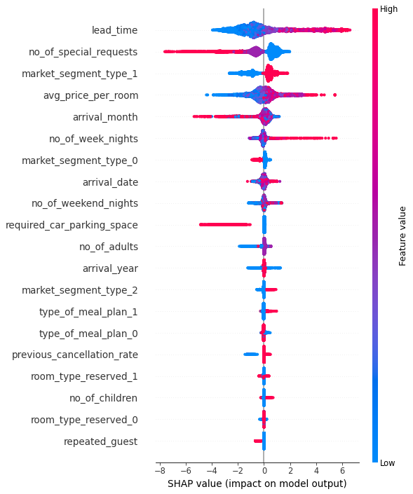

```python
import shap

pipe_xgb = make_pipeline(preprocessor, XGBClassifier(random_state=123, max_depth = 10, n_estimators = 150,
                                                     learning_rate = 0.1, scale_pos_weight = 1))

preprocessor.fit(X_train)

ohe_feature_names = (
    preprocessor.named_transformers_["pipeline-2"]
    .named_steps["onehotencoder"]
    .get_feature_names_out(categorical_features)
    .tolist()
)

feature_names = (
    numeric_features + ohe_feature_names + binary_features
)

X_train_enc = pd.DataFrame(
    data=preprocessor.transform(X_train),
    columns=feature_names,
    index=X_train.index,
)

pipe_xgb.fit(X_train, y_train)

xgb_explainer = shap.TreeExplainer(pipe_xgb.named_steps['xgbclassifier'])

shap_values = xgb_explainer.shap_values(X_train_enc)

plt.figure(figsize=(25,25), dpi=75)

shap.summary_plot(shap_values, X_train_enc)
```

```python
import eli5

eli5.explain_weights(pipe_xgb.named_steps["xgbclassifier"], feature_names=feature_names)
```

| Weight | Feature |
| --- | --- |
| 0.2943 | market_segment_type_1 |
| 0.0913 | no_of_special_requests |
| 0.0739 | required_car_parking_space |
| 0.0570 | lead_time |
| 0.0464 | no_of_adults |
| 0.0396 | market_segment_type_0 |
| 0.0368 | arrival_year |
| 0.0352 | market_segment_type_2 |
| 0.0292 | avg_price_per_room |
| 0.0285 | arrival_month |
| 0.0255 | no_of_previous_bookings_not_canceled |
| 0.0243 | room_type_reserved_4 |
| 0.0213 | no_of_weekend_nights |
| 0.0211 | type_of_meal_plan_2 |
| 0.0199 | type_of_meal_plan_0 |
| 0.0182 | no_of_week_nights |
| 0.0158 | type_of_meal_plan_1 |
| 0.0147 | no_of_children |
| 0.0145 | arrival_date |
| 0.0140 | previous_cancellation_rate |
| *… 11 more …* |  |

The resulting plot displays the feature importance in descending order and the value indicates the magnitude of importance. The important feature is market_segment_type_1.

## 12. Results on the test set

```python
# Use XGBClassifier model
xgb_model = make_pipeline(preprocessor, XGBClassifier(random_state=123, max_depth = 10, n_estimators = 150,
                                                     learning_rate = 0.1, scale_pos_weight = 1))

xgb_model.fit(X_train, y_train)

y_pred = xgb_model.predict(X_test)

f1 = f1_score(y_test, y_pred)

print("F1 score on test data:", f1)
```

```
F1 score on test data: 0.8276255707762558
```

## 13. Explaining predictions

Take one or two test predictions and explain them with SHAP force plots.

```
ntree_limit is deprecated, use `iteration_range` or model slicing instead.
```

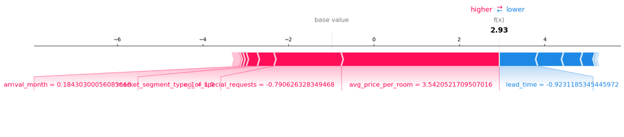

```
The base value is : -0.982895
```

```python
# prediction on 'canceled' (class 1)
y_test_reset = y_test.reset_index(drop=True)

canceled_ind = y_test_reset[y_test_reset == 1].index.tolist()


X_test_enc = pd.DataFrame(
    data=preprocessor.transform(X_test),
    columns=feature_names,
    index=X_test.index,
)

test_xgb_shap_values = xgb_explainer.shap_values(X_test_enc)

plt.figure(figsize=(25,25), dpi=75)

shap.force_plot(
    xgb_explainer.expected_value,
    test_xgb_shap_values[canceled_ind[0], :],
    X_test_enc.iloc[canceled_ind[0], :],
    matplotlib=True,
)

print('The base value is :', xgb_explainer.expected_value)
```